# mean-shift, normalized cut and blob detection

```python
# loading required packages
import numpy as np
import pandas as pd
import matplotlib.pyplot as plt
import cv2
%matplotlib inline

# algorithms for mean shift
from sklearn.cluster import MeanShift, estimate_bandwidth
from skimage.color import rgb2hsv, rgb2gray
from skimage import io
from sklearn import preprocessing

# normalized cut
from skimage.future import graph
from skimage import segmentation, color

# blob detection
from skimage.feature import blob_log
from skimage import util

#
import math

# current work
import os
os.getcwd()
```

```
'/home/guanshim/Documents/image_data/bio_image'
```

## Mean-shift for Image Segmentation

Mean-shift is a clustering-based segmentation method. This algorithm will seek the modes of density in the 2d feature space, by shifting the search window to the weighted mean of points in the window until convergence.  
In detail, this method uses the multivariate kernel density function $\hat{f}(x)$ with a bandwidth $h$ to transform the data points to the feature space. The gradient of the $\hat{f}(x)$ , which is the $\nabla\hat{f}(x) = 0 $ can lead us the Mean-shift vector.

### Apply mean shift to image segmentation, and compare using only color values and color values + position information

You can use RGB or other color values as the feature vector for each pixel. Select a kernel (e.g., flat kernel, Gaussian kernel, etc.) and a proper bandwidth parameter value, and segment the images.

```python
# img files for p1
p1 = 'P1_*.jpg'
img = io.imread_collection(p1)
# landscape and mushroom
img1, img2 = img
print(img1.shape)
print(img2.shape)
```

```
(321, 481, 3)
(481, 321, 3)
```

Using numpy reshape to get the 3d features, where the column 0 to 2 corresponding to R, G, B channels and the number of rows equals to the $height \times width$ of the original image. The way this function reshaping the 3d image array to 2d array is to stack the intensity value by row first then by the columns.  
The features should be normalized. The R, G, B value can be normalized by dividing 255.0 or rescald to mean 0 and unit variance. The coordinates can also be rescaled.  
Different normalization methods might be suitable for different images.

```python
sum(np.reshape(img1, [-1, 3])[:481, 0] == img1[0, :, 0])
```

```
481
```

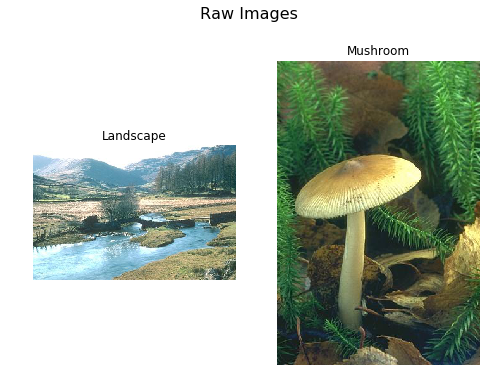

```python
fig = plt.figure(figsize=(8, 6))
ax = []
fig.suptitle("Raw Images", fontsize=16)

ax.append(fig.add_subplot(1, 2, 1))
ax[-1].set_title("Landscape")
plt.imshow(img1)
plt.axis("off")

ax.append(fig.add_subplot(1, 2, 2))
ax[-1].set_title("Mushroom")
plt.imshow(img2)
plt.axis("off")

plt.show()
```

Mean shift clustering using a **flat kernel** (sklearn.cluster.MeanShift).

```python
def mean_shift_wrapper1(img, bandwidth = None):
    """
    A wrapper color img mean shift segmentation
    Rescaled to mean 0 and unit variance
    """
    # color values + position information are always required
    # h is the nrow, w is ncol
    h, w = img[:, :, 0].shape
    # img_3d = np.reshape(img, [-1, 3])
    d3 = np.reshape(img, [-1, 3])
    img_3d = np.hstack((preprocessing.scale(d3[:, 0]).reshape(-1, 1), preprocessing.scale(d3[:, 1]).reshape(-1, 1), preprocessing.scale(d3[:, 2]).reshape(-1, 1)))
    # img_3d = np.reshape(img, [-1, 3])/255.0
    # get the row, col position
    # row = np.repeat(np.linspace(1, h, h), w).reshape(-1, 1)/h
    # col = np.tile(np.linspace(1, w, w), h).reshape(-1, 1)/w
    row = preprocessing.scale(np.repeat(np.linspace(1, h, h), w).reshape(-1, 1))
    col = preprocessing.scale(np.tile(np.linspace(1, w, w), h).reshape(-1, 1))
    img_5d = np.hstack((img_3d, row, col))
    # print the bandwidth estimated to get the hints
    bandwidth_3d = estimate_bandwidth(img_3d, quantile=.2, n_samples=500)
    bandwidth_5d = estimate_bandwidth(img_5d, quantile=.2, n_samples=500)
    print("Bandwidth of 3d feature and 5d feature: %f and %f, respectively" % (bandwidth_3d, bandwidth_5d))
    if not bandwidth:
        ms_3d = MeanShift(bandwidth_3d, bin_seeding=True)
        ms_3d.fit(img_3d)
        labels_3d = ms_3d.labels_
        labels_unique_3d = np.unique(labels_3d)
        n_clusters_3d = len(labels_unique_3d)
        print("number of estimated clusters for 3d feature: %d" % n_clusters_3d)
        ms_5d = MeanShift(bandwidth_5d, bin_seeding=True)
        ms_5d.fit(img_5d)
        labels_5d = ms_5d.labels_
        labels_unique_5d = np.unique(labels_5d)
        n_clusters_5d = len(labels_unique_5d)
        print("number of estimated clusters for 5d feature: %d" % n_clusters_5d)

        ## plot
        fig = plt.figure(figsize=(8, 6))
        ax = []
        fig.suptitle("Flat Kernel Mean-Shift Segmentation", fontsize=16)
        ax.append(fig.add_subplot(1, 2, 1))
        ax[-1].set_title("3D Feature")
        plt.imshow(np.reshape(labels_3d, [h, w]))
        plt.axis("off")

        ax.append(fig.add_subplot(1, 2, 2))
        ax[-1].set_title("5D Feature")
        plt.imshow(np.reshape(labels_5d, [h, w]))
        plt.axis("off")

        plt.show()
    elif bandwidth is not None:
        ms_5d = MeanShift(bandwidth, bin_seeding=True)
        ms_5d.fit(img_5d)
        labels_5d = ms_5d.labels_
        labels_unique_5d = np.unique(labels_5d)
        n_clusters_5d = len(labels_unique_5d)
        print("number of estimated clusters for 5d feature: %d" % n_clusters_5d)

        plt.imshow(np.reshape(labels_5d, [h, w]))
        plt.suptitle("Segmentation with 5D Feature by Bandwidth " + str(bandwidth))
        plt.axis('off')

        plt.show()

def mean_shift_wrapper2(img, bandwidth = None):
    """
    A wrapper color img mean shift segmentation
    No normalization
    """
    # color values + position information are always required
    # h is the nrow, w is ncol
    h, w = img[:, :, 0].shape
    img_3d = np.reshape(img, [-1, 3])
    # d3 = np.reshape(img, [-1, 3])
    # img_3d = np.hstack((preprocessing.scale(d3[:, 0]).reshape(-1, 1), preprocessing.scale(d3[:, 1]).reshape(-1, 1), preprocessing.scale(d3[:, 2]).reshape(-1, 1)))
    # img_3d = np.reshape(img, [-1, 3])/255.0
    # get the row, col position
    row = np.repeat(np.linspace(1, h, h), w).reshape(-1, 1)
    col = np.tile(np.linspace(1, w, w), h).reshape(-1, 1)
    # row = preprocessing.scale(np.repeat(np.linspace(1, h, h), w).reshape(-1, 1))
    # col = preprocessing.scale(np.tile(np.linspace(1, w, w), h).reshape(-1, 1))
    img_5d = np.hstack((img_3d, row, col))
    # print the bandwidth estimated to get the hints
    bandwidth_3d = estimate_bandwidth(img_3d, quantile=.2, n_samples=500)
    bandwidth_5d = estimate_bandwidth(img_5d, quantile=.2, n_samples=500)
    print("Bandwidth of 3d feature and 5d feature: %f and %f, respectively" % (bandwidth_3d, bandwidth_5d))
    if not bandwidth:
        ms_3d = MeanShift(bandwidth_3d, bin_seeding=True)
        ms_3d.fit(img_3d)
        labels_3d = ms_3d.labels_
        labels_unique_3d = np.unique(labels_3d)
        n_clusters_3d = len(labels_unique_3d)
        print("number of estimated clusters for 3d feature: %d" % n_clusters_3d)
        ms_5d = MeanShift(bandwidth_5d, bin_seeding=True)
        ms_5d.fit(img_5d)
        labels_5d = ms_5d.labels_
        labels_unique_5d = np.unique(labels_5d)
        n_clusters_5d = len(labels_unique_5d)
        print("number of estimated clusters for 5d feature: %d" % n_clusters_5d)

        ## plot
        fig = plt.figure(figsize=(8, 6))
        ax = []
        fig.suptitle("Flat Kernel Mean-Shift Segmentation", fontsize=16)
        ax.append(fig.add_subplot(1, 2, 1))
        ax[-1].set_title("3D Feature")
        plt.imshow(np.reshape(labels_3d, [h, w]))
        plt.axis("off")

        ax.append(fig.add_subplot(1, 2, 2))
        ax[-1].set_title("5D Feature")
        plt.imshow(np.reshape(labels_5d, [h, w]))
        plt.axis("off")

        plt.show()
    elif bandwidth is not None:
        ms_5d = MeanShift(bandwidth, bin_seeding=True)
        ms_5d.fit(img_5d)
        labels_5d = ms_5d.labels_
        labels_unique_5d = np.unique(labels_5d)
        n_clusters_5d = len(labels_unique_5d)
        print("number of estimated clusters for 5d feature: %d" % n_clusters_5d)

        plt.imshow(np.reshape(labels_5d, [h, w]))
        plt.suptitle("Segmentation with 5D Feature by Bandwidth " + str(bandwidth))
        plt.axis('off')

        plt.show()
```

With rescaling normalization for figure 1.

```
Bandwidth of 3d feature and 5d feature: 0.946668 and 1.966131, respectively
number of estimated clusters for 3d feature: 3
number of estimated clusters for 5d feature: 2
```

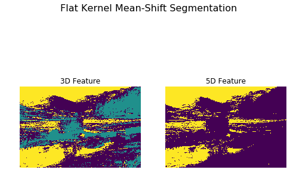

```python
mean_shift_wrapper1(img1)
```

No normalization for figure 2.

```
Bandwidth of 3d feature and 5d feature: 46.631673 and 152.277334, respectively
number of estimated clusters for 3d feature: 2
number of estimated clusters for 5d feature: 3
```

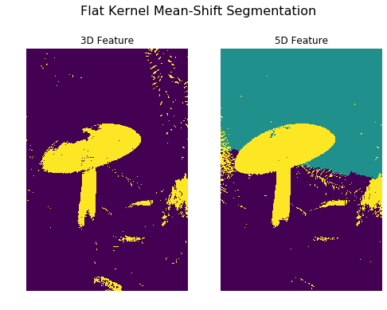

```python
mean_shift_wrapper2(img2)
```

For the mean-shift segmentation method, the bandwidth is the most important parameter.

Theoretically, taking coordinates into accout should have a better segmentation. However, for part 1, I just used the automatically estimated bandwidth. Thus, it seems like adding position information did not improve the performance. However, from the part 2, with 5D features, we can tell the segmentation works very good by adjusting the bindwidth.

### Use color values+position information as the pixel vector, with three different bandwidth values

```
Bandwidth of 3d feature and 5d feature: 0.946668 and 1.966131, respectively
number of estimated clusters for 5d feature: 8
```

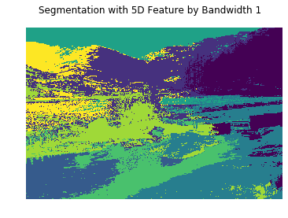

```
Bandwidth of 3d feature and 5d feature: 0.946668 and 1.966131, respectively
```

```
number of estimated clusters for 5d feature: 5
```

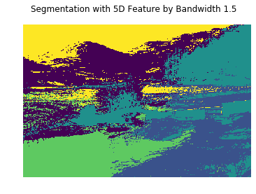

```
Bandwidth of 3d feature and 5d feature: 0.946668 and 1.966131, respectively
```

```
number of estimated clusters for 5d feature: 2
```

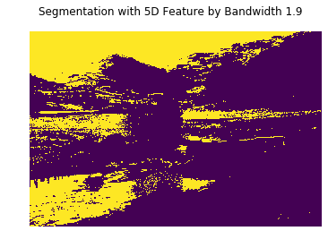

```python
mean_shift_wrapper1(img1, 1)
mean_shift_wrapper1(img1, 1.5)
mean_shift_wrapper1(img1, 1.9)
```

```
Bandwidth of 3d feature and 5d feature: 0.986315 and 1.893153, respectively
number of estimated clusters for 5d feature: 7
```

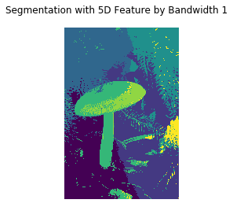

```
Bandwidth of 3d feature and 5d feature: 0.986315 and 1.893153, respectively
```

```
number of estimated clusters for 5d feature: 4
```

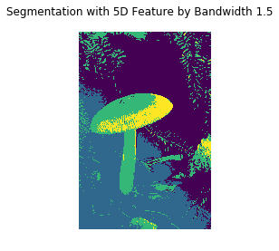

```
Bandwidth of 3d feature and 5d feature: 0.986315 and 1.893153, respectively
```

```
number of estimated clusters for 5d feature: 2
```

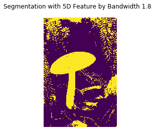

```python
mean_shift_wrapper1(img2, 1)
mean_shift_wrapper1(img2, 1.5)
mean_shift_wrapper1(img2, 1.8)
```

With smaller bindwidth, we got more complex segmentation when we were using 5D features. Basically, it depends on the requirement to choose which bandwidth to use. Even with larger bindwidth, the binary segmentation seems very reasonable.

## Apply normalized cut to image segmentation

Normalized cut was improved upon minimum cut and is based on the graph theory. Because the biggest drawback of minimum cut is that the minimum cut is in favor of cutting small sets of isolated nodes.
Thus, normalized cut was designed to minimize: $$Ncut(A, B) = \frac{cut(A, B)}{assoc(A, V)} + \frac{cut(A, B)}{assoc(B, V)}$$
The edges in the graph is defined by some measurement of similarities.

Since each pixel will be considered as a node in the graph, it is common to use superpixel to reduce the number of edges and computations in the normalized cut.

Simple linear iterative clustering (SLIC): use K-means clustering to generate superpixels.

The compactness is the weight to balance the color and spatial information. Higher values give more weight to space proximity, making superpixel shapes more square/cubic.

```python
def slic(img):
    weight = [0.01, 0.1, 1, 10, 15, 20]
    fig, ax = plt.subplots(nrows = len(weight), sharex=True, sharey=True, figsize=(12, 16))
    for i in range(len(weight)):
        w = weight[i]
        labels1 = segmentation.slic(img, compactness=w, n_segments=400)
        out1 = color.label2rgb(labels1, img, kind='avg')
        ax[i].imshow(out1)

    for i, a in enumerate(ax):
        a.axis('off')
        w = weight[i]
        a.set_title("Compactness " + str(w) )
    plt.show()
```

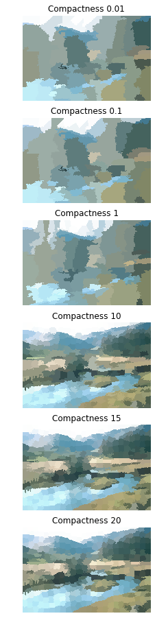

```python
slic(img1)
```

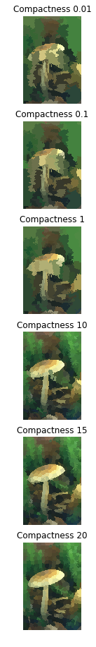

```python
slic(img2)
```

```python
def slic_norm(img, weight):
    # superpixel
    labels1 = segmentation.slic(img, compactness = weight, n_segments=400)
    out1 = color.label2rgb(labels1, img, kind='avg')
    #  cut
    g = graph.rag_mean_color(img, labels1, mode='similarity')
    labels2 = graph.cut_normalized(labels1, g)
    out2 = color.label2rgb(labels2, img, kind='avg')
    # plot
    fig, ax = plt.subplots(nrows=2, sharex=True, sharey=True, figsize=(6, 8))
    ax[0].imshow(out1)
    ax[0].set_title("SLIC Superpixel" + str(weight) )
    ax[1].imshow(out2)
    ax[1].set_title("Normalized Cut")
    for i, a in enumerate(ax):
        a.axis('off')

    plt.show()
```

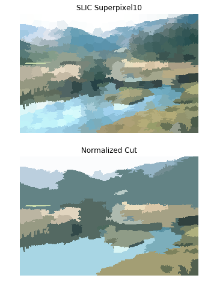

```python
slic_norm(img1, 10)
```

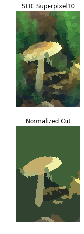

```python
slic_norm(img2, 10)
```

With the normalized cut function by **skimage**, the result is highly dependent on the superpixels. Overall, compared with the mean-shift method in problem 1, the normalized cut based on SLIC superpixel is good at detecting objects but not good at getting fine edges.

## Blob detection using scaled-normalized Laplacian of Gaussian (LoG)

The scaled-normalized Laplacian of Gaussian (LoG) is defined as: $$\sigma^2LoG(x,y) = \sigma^2(\Delta^2_x G_{\sigma}(x,y) + \Delta^2_y G_{\sigma}(x,y))$$ Which is: $$\sigma^2LoG(x,y) = -\frac{1}{\pi\sigma^2}[1 - \frac{x^2+y^2}{2\sigma^2}]\exp{(-\frac{x^2 + y^2}{2\sigma^2})}$$

The kernel size of the LoG was chosen as $6\sigma + 1$

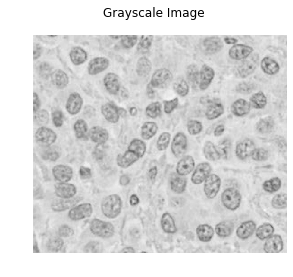

```python
img = cv2.imread("P3_nuclei.png")
cimg = cv2.cvtColor(img, cv2.COLOR_BGR2GRAY)

plt.axis("off"), plt.suptitle('Grayscale Image')
plt.imshow(cimg, cmap = 'gray')
plt.show()
```

Weights of LoG sum up to 0 not 1.

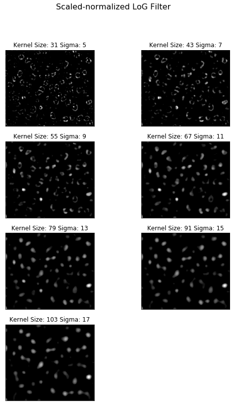

```python
img = cv2.imread("P3_nuclei.png")
cimg = cv2.cvtColor(img, cv2.COLOR_BGR2GRAY)

fig = plt.figure(figsize=(9, 13))
ax = []
for i in range(5,19,2):
    size = int(6*i + 1)
    j = int((i-1)/2 - 1)
    sigma = i
    kernel = np.fromfunction(lambda x, y: (1/ (math.pi*(sigma**2) )) *(( (x-(size-1)/2)**2+(y-(size-1)/2)**2)/(2*sigma**2) - 1 )* (math.e ** ((-1*((x-(size-1)/2)**2+(y-(size-1)/2)**2))/(2*sigma**2)) ), (size, size))
    # kernel /= np.sum(kernel)
    # Scaled-normalized
    # kernel *= sigma**2
    LoG = cv2.filter2D(cimg, -1, kernel)
    fig.suptitle("Scaled-normalized LoG Filter", fontsize=16)
    ax.append(fig.add_subplot(4, 2, j))
    ax[-1].set_title("Kernel Size: " + str(size) + " Sigma: "+ str(i))
    plt.imshow(LoG, cmap = 'gray', interpolation='none')
    plt.xticks([]), plt.yticks([]) # to hide tick values on X and Y axis
plt.show()
```

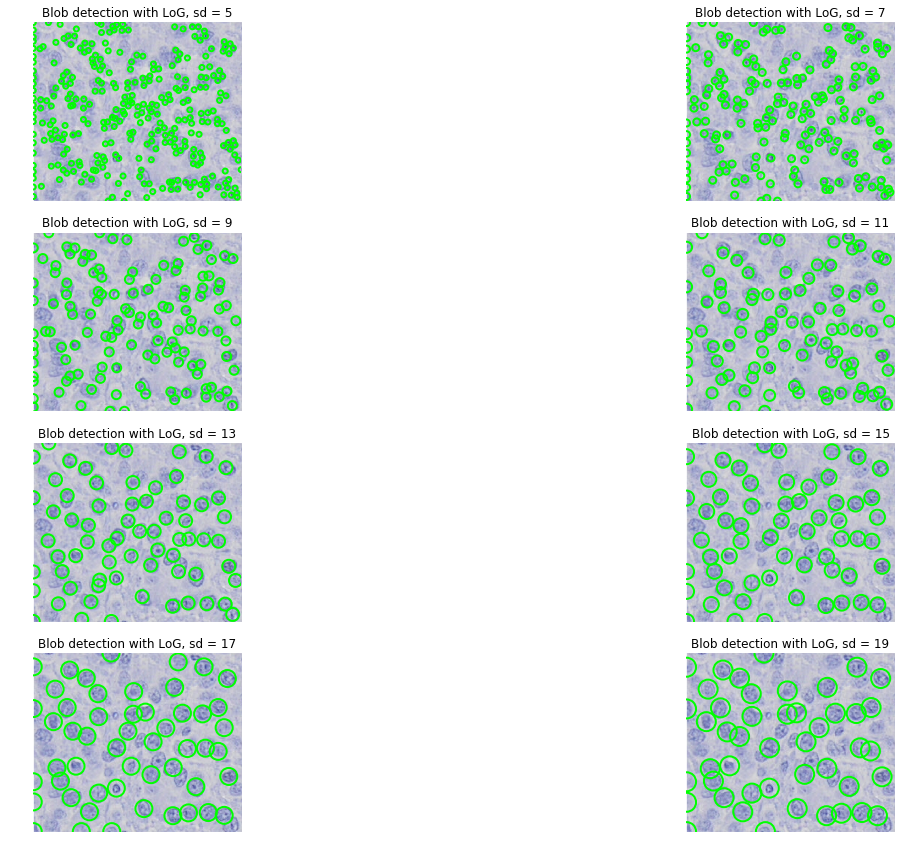

```python
img = io.imread("P3_nuclei.png")
# invert the black and white
cimg = util.invert(rgb2gray(img))

fig, axes = plt.subplots(4, 2, sharex=True, sharey=True, figsize=(24, 12))
ax = axes.ravel()

for i in range(5,21,2):
    j = int((i-1)/2 - 2)
    sigma = i
    blobs_log = blob_log(cimg, min_sigma=sigma, max_sigma=sigma,num_sigma=1,threshold=.05)
    # Compute radii in the 3rd column.
    blobs_log[:, 2] = blobs_log[:, 2] * math.sqrt(2)
    # plot
    ax[j].imshow(img, interpolation='nearest')
    ax[j].set_title("Blob detection with LoG, sd = " + str(sigma))
    ax[j].set_axis_off()
    for blob in blobs_log:
        y, x, r = blob
        c = plt.Circle((x, y), r, color = "lime", linewidth=2, fill=False)
        ax[j].add_patch(c)


plt.tight_layout()
plt.show()
```

With this function, blobs are found using the Laplacian of Gaussian (LoG) method.  
The standard deviation for Gaussian kernel is the most important parameter. Keep this low to detect smaller blobs. Keep this high to detect larger blobs. And reducing the threshold can detect blobs with less intensities.